# HW6

Use this R Notebook document to answer the questions and document your work. Enter the R code used to answer each question in the corresponding R code chunk. Write any textual explanations **outside** of the chunks. When we grade, we will *hide* the code and just look at the R output and your written answers. Attempt to clean up your code as much as possible so that only the necessary lines remain.

When you are done:

1. Select ‘**Restart R and Run All Chunks**’ from the ‘Run’ dropdown menue.
2. Save (File -> Save)
3. Click ‘Preview’ to bring up the `HW6.nb.html` file. Check through this to make sure it rendered correctly.
4. Upload the `HW6.nb.html` to Canvas.

Necessary libraries

## 0.1 Question 1

A researcher was interested in examining the effect of pasture species composition on beta-carotene content in eggs of pastured poultry. She evenly divided each of four fields into five sections and overseeded each section with one of the following: 1) annual rye (grass); 2) fescue (grass); 3) white clover (legume); 4) vetch (legume); or, 5) clover/fescue mix. A separate flock of 10 birds was put out in each section. After one-week, eggs from each flock were collected daily and combined for determining beta-carotene content of the yolks. These values in $\mu_g/g$ were averaged after 10 days.

```
'data.frame':   20 obs. of  4 variables:
 $ Field  : chr  "F1" "F1" "F1" "F1" ...
 $ Species: chr  "Species_1" "Species_5" "Species_3" "Species_2" ...
 $ Section: Factor w/ 5 levels "1","2","3","4",..: 1 2 3 4 5 1 2 3 4 5 ...
 $ Beta   : num  3.38 3.64 3.49 3.26 3.5 ...
```

### 0.1.1 1.1 Describe the design of this experiment in detail.

**Design**: **Response**:

| Structure | Variable | Type | # levels | Blocks | EU |
| --- | --- | --- | --- | --- | --- |
| Treatment | Species | Categorical | 5 | Field | Section |
| Design | Field | Categorical | 4 |  |  |
|  | Species:Field | Categorical | 20 |  |  |
|  | Section | Categorical | 20 |  |  |
| Response | Beta | Numerical | 20 |  |  |

> So this is just an RCBD experiment, with a single treatment and response variable of interest with no moderators. Each field (block) is a replicate (sort of, they do have all the same treatments) of the other, receiving all 5 species, and each section in the field is the experimental unit, receiving one species each.

### 0.1.2 1.2 Assess whether the assumptions of a linear model are adequately satisfied.

Regardless of what you find, do not do a transformation for the rest of the questions.

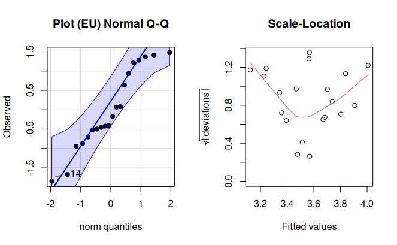

> While normality looks fine, our variance is all over the place. This is not satisfying our assumptions, but different variances between blocks/fields is fine, really, since we’re not interested in the effect field is playing on our response variable.

### 0.1.3 1.3 Estimate the differences between all pairs of pasture covers. Include appropriate units based on your choice of transformation (or no transformation)

```
 Species_effect_on_beta estimate     SE df t.ratio p.value
 Species_1 - Species_2   -0.1017 0.0875 12  -1.163  0.7714
 Species_1 - Species_3   -0.2351 0.0875 12  -2.688  0.1148
 Species_1 - Species_4   -0.2707 0.0875 12  -3.094  0.0585
 Species_1 - Species_5   -0.4401 0.0875 12  -5.032  0.0022
 Species_2 - Species_3   -0.1334 0.0875 12  -1.525  0.5667
 Species_2 - Species_4   -0.1690 0.0875 12  -1.932  0.3526
 Species_2 - Species_5   -0.3385 0.0875 12  -3.869  0.0155
 Species_3 - Species_4   -0.0356 0.0875 12  -0.407  0.9935
 Species_3 - Species_5   -0.2050 0.0875 12  -2.344  0.1968
 Species_4 - Species_5   -0.1695 0.0875 12  -1.937  0.3501

Results are averaged over the levels of: Field
P value adjustment: tukey method for comparing a family of 5 estimates
 Species   emmean     SE df lower.CL upper.CL .group
 Species_1   3.35 0.0619 12     3.22     3.49  a
 Species_2   3.45 0.0619 12     3.32     3.59  a
 Species_3   3.59 0.0619 12     3.45     3.72  ab
 Species_4   3.62 0.0619 12     3.49     3.76  ab
 Species_5   3.79 0.0619 12     3.66     3.93   b

Results are averaged over the levels of: Field
Confidence level used: 0.95
P value adjustment: tukey method for comparing a family of 5 estimates
significance level used: alpha = 0.05
NOTE: If two or more means share the same grouping symbol,
      then we cannot show them to be different.
      But we also did not show them to be the same.
```

> Well, as per the previous question, I’m not transforming the data at all (since I was told not to), so the average differences are in units of micrograms of beta-carotene per gram of egg.

### 0.1.4 1.4 Is there any evidence of an interaction between Field and Species cover? ie. do differences among covers change across the fields?

Is the interaction replicated? If not, you can’t answer this question with an ANOVA, but you can tentatively assess with an interaction plot. Describe whether it looks like there are large interactions present.

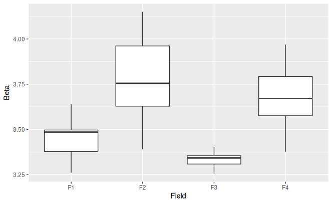

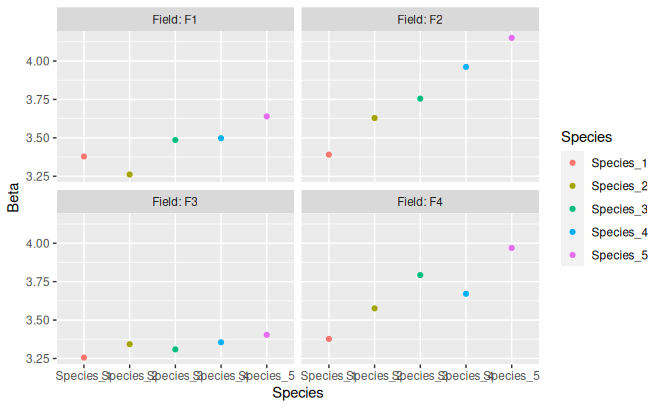

> There’s no real replication going on here; each `Field` is only represented once. Tentatively, there does seem to be some interaction between Field and Species, since certain fields, like F2 and F4, have a much wider range between the covers, and F1 and F3’s covers are relatively close.

### 0.1.5 1.5 Did the researcher gain information by utilizing a RCBD relative to a CRD where the sections of all fields were randomized together?

```
Analysis of Variance Table

Response: Beta
          Df  Sum Sq  Mean Sq F value Pr(>F)
Species    4 0.45244 0.113109  2.1132 0.1297
Residuals 15 0.80288 0.053526
```

> Yes! Accounting for the differences between fields means we do see strong evidence of at least a few species specific effects (specifically Species 1 and 2 to Species 5), that do not show up when ignoring the fields (i.e., we fail to reject the null hypothesis).

### 0.1.6 1.6 Instead of randomizing all 5 plots on the 4 fields together, speculate on the efficiency had she used only one field.

In this case, to maintain the same replication, she would divide it into 20 smaller plots, and use only 2 birds per plot (instead of 10). Speculate on how the MSE/
$$s^2$$
would compare to the original RCBD, or the CRD over the four fields. **Is there any advantage to spreading the experiment over 4 fields** Is there any disadvantage?

> Our MSE for this new smaller plot design would be the same for the CRD, since both would have the same number of independent EUs. Our RCBD has less df than our CRD and therefore also the single plot design, so really the main difference for the smaller design is the sample size and field effects. Sample size of 2 does make our error bigger and reduce the confidence we have in our estimates, so spreading out over 4 fields for either CRD or RCBD does help reduce error in that way, but we’re fairly confident that the fields do have effect on the differences between covers, which is the downside to spreading out over 4 fields.

### 0.1.7 1.7 Add 1 $\mu g/g$ to each value in Field F4. Does this produce any effect on the SS_Species, MS_Species, or F-value? Explain why or why not in one sentence.

In this case (with Field F4 being much more productive), did the importance of Blocking increase or decrease?

The following code makes a modified dataset with the increase of 1 in the Beta values for Field F4

```
[1] "Original Model:"
Analysis of Variance Table

Response: Beta
          Df  Sum Sq  Mean Sq F value    Pr(>F)
Species    4 0.45244 0.113109  7.3912 0.0030504 **
Field      3 0.61925 0.206415 13.4883 0.0003764 ***
Residuals 12 0.18364 0.015303
---
Signif. codes:  0 ‘***’ 0.001 ‘**’ 0.01 ‘*’ 0.05 ‘.’ 0.1 ‘ ’ 1
[1] "F4 Productive Model:"
Analysis of Variance Table

Response: Beta
          Df Sum Sq Mean Sq  F value    Pr(>F)
Species    4 0.4524 0.11311   7.3912   0.00305 **
Field      3 5.5407 1.84690 120.6872 3.152e-09 ***
Residuals 12 0.1836 0.01530
---
Signif. codes:  0 ‘***’ 0.001 ‘**’ 0.01 ‘*’ 0.05 ‘.’ 0.1 ‘ ’ 1
[1] "F4 boosted, no blocking:"
Analysis of Variance Table

Response: Beta
          Df Sum Sq Mean Sq F value Pr(>F)
Species    4 0.4524 0.11311  0.2964 0.8757
Residuals 15 5.7244 0.38162
```